# Hypothesis Testing via Lady Tasting Tea

Albert Y. Kim

Mon Nov 7, 2016

## Competing Hypotheses

Recall the two competing hypotheses:

1. She truly has the ability to tell which came first: milk or tea.
2. She is just guessing.

**Key**: Let’s suppose 2 is true; suppose she is guessing.

## Learning Check

1. See if using the `resample()` and `do()` commands you can
   - simulate many, many, many cases of someone guessing at random for the eight cups, then
   - count the number of correct guesses
2. How would you compare
   - the **observed** number of correct guesses (in this case 8)
   - to the **typical** number of correct guesses assuming she is guessing at random?

## Solution

#### 1. Simulating someone guessing at random for 8 cups many, many, many times

```r
library(ggplot2)
library(dplyr)
library(mosaic)

# Single cup
guess_cup <- c(1, 0)

# Simulate many, many, many times someone guessing at random
simulation <- do(10000) * resample(guess_cup, size=8)
```

| V1 | V2 | V3 | V4 | V5 | V6 | V7 | V8 |
| --- | --- | --- | --- | --- | --- | --- | --- |
| 0 | 0 | 0 | 1 | 1 | 1 | 0 | 0 |
| 0 | 0 | 0 | 1 | 1 | 1 | 1 | 1 |
| 1 | 0 | 0 | 1 | 1 | 0 | 1 | 0 |
| 1 | 1 | 1 | 1 | 1 | 0 | 1 | 0 |
| 1 | 0 | 0 | 0 | 0 | 0 | 0 | 1 |
| 1 | 0 | 1 | 0 | 0 | 1 | 1 | 1 |

#### 2. Count the number of correct guesses

```r
simulation <- simulation %>%
  mutate(n_correct = V1 + V2 + V3 + V4 + V5 + V6 + V7 + V8)
```

| V1 | V2 | V3 | V4 | V5 | V6 | V7 | V8 | n_correct |
| --- | --- | --- | --- | --- | --- | --- | --- | --- |
| 0 | 0 | 0 | 1 | 1 | 1 | 0 | 0 | 3 |
| 0 | 0 | 0 | 1 | 1 | 1 | 1 | 1 | 5 |
| 1 | 0 | 0 | 1 | 1 | 0 | 1 | 0 | 4 |
| 1 | 1 | 1 | 1 | 1 | 0 | 1 | 0 | 6 |
| 1 | 0 | 0 | 0 | 0 | 0 | 0 | 1 | 2 |
| 1 | 0 | 1 | 0 | 0 | 1 | 1 | 1 | 5 |

#### 3. What is typical number of correct guesses assuming she is guessing at random?

i.e. What is the distribution of `n_correct`?

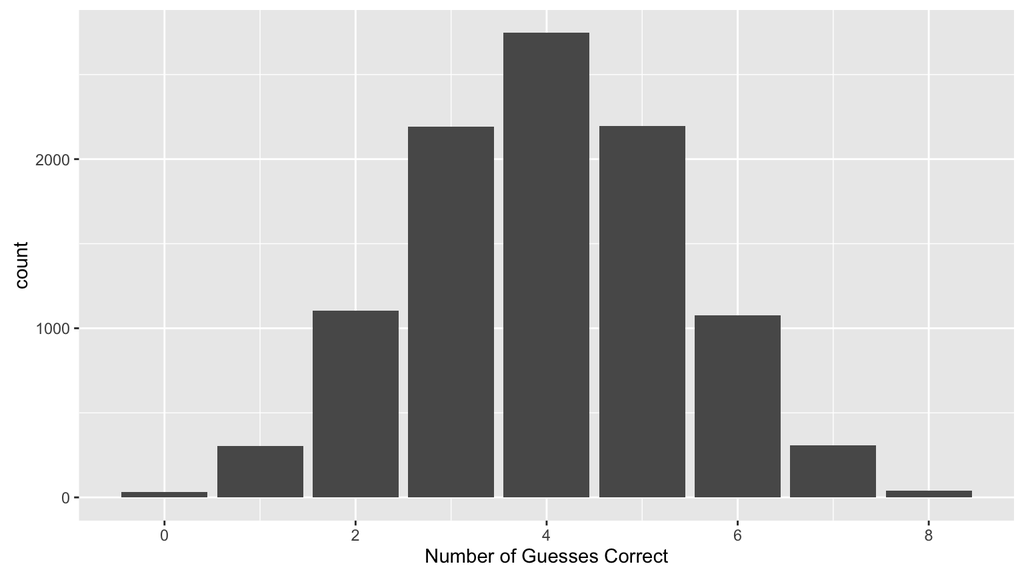

```r
ggplot(simulation, aes(x=n_correct)) +
  geom_bar() +
  labs(x="Number of Guesses Correct")
```

#### 4. Compare to observed number correct

i.e. she got 8/8 correct. We add a vertical red line:

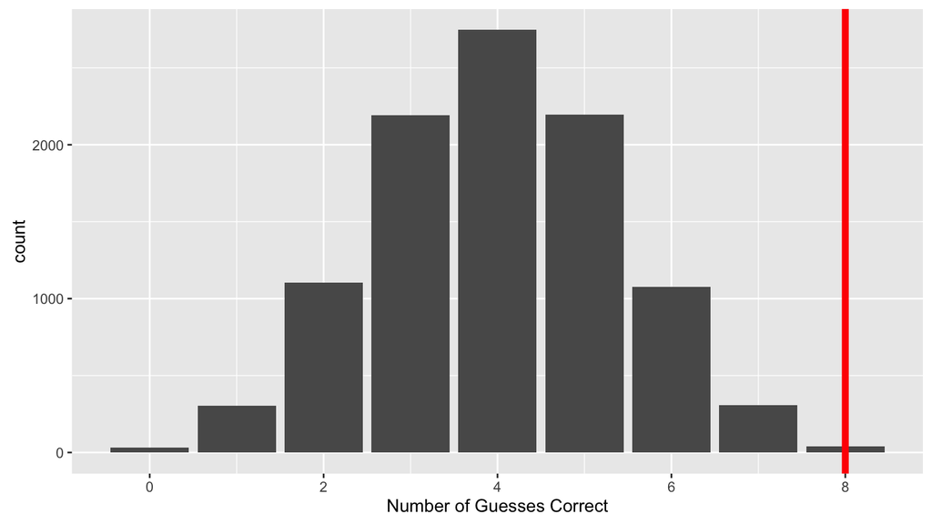

```r
ggplot(simulation, aes(x=n_correct)) +
  geom_bar() +
  labs(x="Number of Guesses Correct") +
  geom_vline(xintercept=8, col="red", size=2)
```

## Questions

1. If she were truly guessing at random, how likely is it that she gets 8/8 correct?
2. What does the observed data say about the hypothesis that she was guessing at random?